# Q6-Comparing_models g.sm vs g.big

```r
library(HistData)

library(ggplot2)

install.packages<-contrib.url

data(GaltonFamilies)
Galton2 <- data.frame(GaltonFamilies)
```

1. Fit the following model for childHeight, g.big: $childHight = \beta_0 + \beta_1gender + \beta_2father + \beta_3mother + \beta_4children$. What are the estimated coefficients, standard errors of estimate, t-values of estimate, and p-values of estimate?

```r
g.big<-lm(childHeight~gender+father+mother+children,Galton2)
summary(g.big)$coeff
```

```
##                Estimate Std. Error   t value      Pr(>|t|)
## (Intercept) 17.43102973 2.77406863  6.283561  5.079644e-10
## gendermale   5.19852104 0.14197155 36.616640 2.093140e-182
## father       0.38521395 0.02898001 13.292403  4.892948e-37
## mother       0.31618779 0.03097755 10.206997  2.950867e-23
## children    -0.04573175 0.02630931 -1.738235  8.250078e-02
```

Fit the following model for childHeight, g.sm: $childHight = \beta_0 + \beta_1gender + \beta_2father$. What are the estimated coefficients, standard errors of estimate, t-values of estimate, and p-values of estimate?

```r
g.sm<-lm(childHeight~gender+father, Galton2)
summary(g.sm)$coeff
```

```
##               Estimate Std. Error  t value      Pr(>|t|)
## (Intercept) 35.6790984 2.09313335 17.04578  6.533613e-57
## gendermale   5.1804523 0.14947528 34.65759 1.054827e-169
## father       0.4104067 0.03018159 13.59792  1.518043e-38
```

For the test of the model g.sm vs the model g.big, in terms of the beta coefficients what are the null and alternative hypotheses for this statistical test?

H0: $\beta_3mother + \beta_4children=0$

H1: $\beta_3mother + \beta_4children\ne 0$

4. Compute the Analysis of Variance Table for this test based on the data.

```r
anova(g.sm,g.big)
```

```
## Analysis of Variance Table
##
## Model 1: childHeight ~ gender + father
## Model 2: childHeight ~ gender + father + mother + children
##   Res.Df    RSS Df Sum of Sq      F    Pr(>F)
## 1    931 4849.7
## 2    929 4343.7  2    505.99 54.108 < 2.2e-16 ***
## ---
## Signif. codes:  0 '***' 0.001 '**' 0.01 '*' 0.05 '.' 0.1 ' ' 1
```

5. Using $\alpha = 0.001$, based on the p-value, what is the decision rule and conclusion of the hypotheses test of $g.sm$ versus $g.big$?

Decision rule- if $p<alpha = 0.001$ reject H0 if $p>alpha = 0.001$, accept H0

Conclusion- We reject H0 and accepts that ‘mother’ and ‘children’ predicts ’Childheight

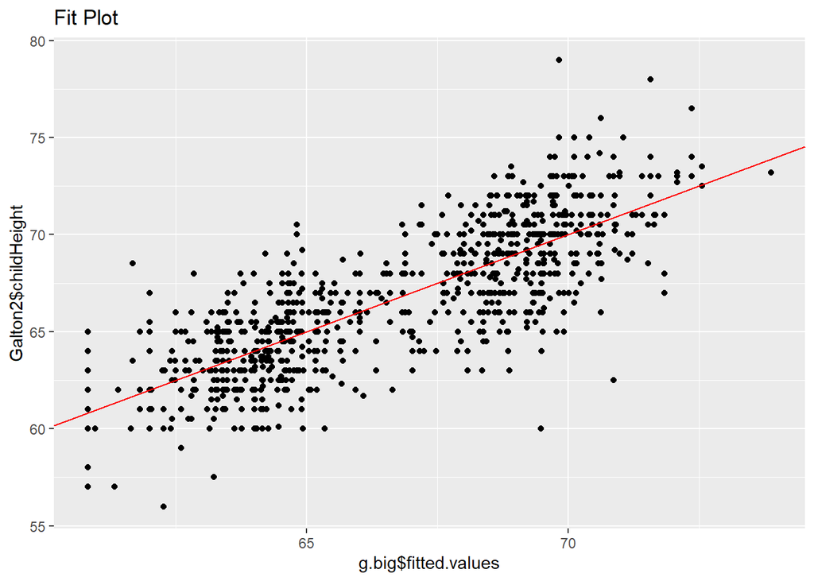

```r
p5<-ggplot(data=g.big, aes(x=g.big$fitted.values, y=Galton2$childHeight))+
  geom_point()+
  geom_abline (intercept=0,slope=1, col='red')+
  labs(title = 'Fit Plot')

p5
```

What is the Pearson correlation between the g.big fitted-values and actual-values

```r
p<-cor(g.big$fitted.values,Galton2$childHeight)
p
```

```
## [1] 0.797865
```

8. Is the correlation strong, moderate or weak?

Ans- The correlation is strong

9. What does this indicate for the model?

Ans- This indicate that model’s predicted values and actual values are highly correlated. Therefore our model is good.

10. What is the $R^2$ for the g.big model?

```r
summary(g.big)$r.square
```

```
## [1] 0.6365886
```

11.What does $R^2$ mean for the fitted model?

Ans- R square indicates the precision of the model to predict the dependent variables as close to the actual data. Another way to explain is R2 is the percentage of variation in actual Y-values explained by the fitted Y values

12. Theoretically, what is the relation between the $R^2$ and the Pearson correlation (actual y-values vs fitted-values)?

Ans- R2 is square of Pearson correlation between the actual Y value and the predicted Y values

13.Show that this relation holds for the computed values of the g.big?

```r
rsqr=summary(g.big)$r.square
p_sqr=(p^2) # where p is the Pearson correlation between the g.big fitted-values and actual-values from Q.7

((rsqr)); ((p_sqr))
```

```
## [1] 0.6365886
```

```
## [1] 0.6365886
```